# behavioral results

The raw data are stored in the subfolder `data`. Let’s read in.

```r
library(tidyverse)
library(MASS)
library(lme4)
library(lmerTest)
library(sjPlot)
raw = read.csv('../data/AllValidData.csv')
# experiment as a factor
raw$Exp = as.factor(raw$Exp)
# set unique subject No. and as a factor, SubNo. 10#, 20#...
raw$NSub = as.numeric(raw$Exp)*100 + raw$NSub

head(raw)
```

|  | WMSize | DurLevel | TPresent | NT | NSub | curDur | repDur | WMRP | valid | stdRepDur | Exp | gap | log_RP | log_dur | Gap |
| --- | --- | --- | --- | --- | --- | --- | --- | --- | --- | --- | --- | --- | --- | --- | --- |
| 1 | 3 | 1 | 1 | 1 | 101 | 0.5 | 0.7420385 | 2 | 1 | 0.2037006 | Exp1 | 1 | -0.2983542 | -0.69314718 | 500 |
| 2 | 3 | 4 | 1 | 2 | 101 | 1.4 | 1.3019032 | 1 | 1 | 0.2971834 | Exp1 | 1 | 0.2638272 | 0.33647224 | 500 |
| 3 | 3 | 3 | 1 | 3 | 101 | 1.1 | 0.8059575 | 1 | 1 | 0.2017906 | Exp1 | 1 | -0.2157243 | 0.09531018 | 500 |
| 4 | 3 | 5 | 2 | 4 | 101 | 1.7 | 1.2539412 | 2 | 1 | 0.1680432 | Exp1 | 1 | 0.2262915 | 0.53062825 | 500 |
| 5 | 3 | 4 | 2 | 5 | 101 | 1.4 | 0.7098907 | 2 | 1 | 0.2971834 | Exp1 | 1 | -0.3426443 | 0.33647224 | 500 |
| 6 | 3 | 1 | 1 | 6 | 101 | 0.5 | 0.5658982 | 1 | 1 | 0.2037006 | Exp1 | 1 | -0.5693410 | -0.69314718 | 500 |

Visualize the mean reproduction biases.

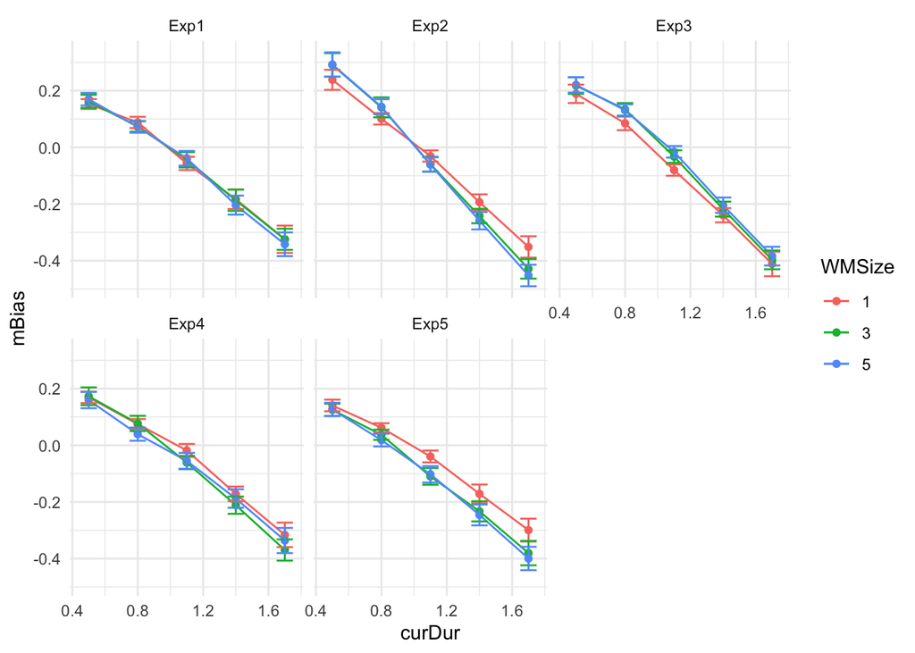

```r
mRep = raw %>% filter(repDur > 0.2, repDur < 4) %>%
  group_by(Exp, NSub, WMSize, curDur) %>%
  summarise(Rep = mean(repDur)) %>%
  mutate(bias = Rep - curDur)

mmRep = mRep%>% #within-subject average
  group_by(Exp, WMSize, curDur) %>%
  summarise(mBias = mean(bias), se = sd(bias)/sqrt(n()), n = n())
mmRep$WMSize = as.factor(mmRep$WMSize)

# visualize the biases
ggplot(data = mmRep, aes(curDur, mBias, color = WMSize)) +
  geom_point() + geom_line() +
  geom_errorbar(aes(ymin = mBias - se, ymax = mBias + se), width = 0.1) +
  facet_wrap(~Exp) + theme_minimal()
```

Preliminary investigation using standard linear model to get first impression.

```r
lm(Rep ~ Exp*curDur*WMSize,
            data = mRep %>% filter(Exp != 'Exp1') )
```

```
##
## Call:
## lm(formula = Rep ~ Exp * curDur * WMSize, data = mRep %>% filter(Exp !=
##     "Exp1"))
##
## Coefficients:
##           (Intercept)                ExpExp3                ExpExp4
##               0.47623               -0.01063               -0.06230
##               ExpExp5                 curDur                 WMSize
##              -0.13228                0.52787                0.03331
##        ExpExp3:curDur         ExpExp4:curDur         ExpExp5:curDur
##              -0.04008                0.04928                0.11056
##        ExpExp3:WMSize         ExpExp4:WMSize         ExpExp5:WMSize
##              -0.02135               -0.03910               -0.02949
##         curDur:WMSize  ExpExp3:curDur:WMSize  ExpExp4:curDur:WMSize
##              -0.03480                0.03326                0.03470
## ExpExp5:curDur:WMSize
##               0.01790
```

It seems that working memory impacts on the central tendency, as the interaction term WMSize x Duration varied across experiments.

To make a formal analysis, we use linear mixed model. Given that Experiment 1 was a baseline checking the duration reproduciton was not impacted by the sequential presentation, we leave this experiment out for cross-experiment analysis.

Given that we are interested how memory manipulation influence duration reproduction on the encoding and reproduction stages, the cross-experiment analysis mainly focuses on the manipulation stage.

Here are the experimental design:

Exp. 2: Memory load on the encoding stage Exp. 3: Memory load on the reproduction stage Exp. 4a (coded: 4): Memory load on both stages Exp. 4b (coded: 5): Memory load on both stage + additional 2 sec gap.

We are interested the following comparisons: 1. encoding vs. reproduction (Exp. 2 vs. Exp. 3) 2. individual impact vs. combination (exp. 2 + exp. 3 vs. Exp. 4a) 3. Gap effect (Exp. 4a vs. 4b )